# PG_10062022

### Stochastic Gradient Descent

```python
from sklearn.linear_model import SGDClassifier

target = dfd['job_result']
features = dfd[selected_GUS]

#Construction of the test and training sample
X_train,X_test,y_train,y_test = train_test_split(features,target,test_size=0.3,random_state=13)

sgd = SGDClassifier()


sgd_ = sgd.fit(X_train,y_train)
target_predict = sgd_.predict(X_test)


print("TEST SAMPLE: ")

acc_sgd = accuracy_score(y_test,target_predict)
print("Perceptron score: ", acc_sgd)

from sklearn.metrics import roc_auc_score
AUC_sgd=roc_auc_score(y_test, target_predict)
print("AUC: ", AUC_sgd)

print ("MSE    :",mean_squared_error(y_test,target_predict))
```

```
TEST SAMPLE:
Perceptron score:  0.8102766798418972
AUC:  0.522512315270936
MSE    : 0.18972332015810275
```

**Summary of the model selection**

```python
models = pd.DataFrame({
    'Model': ['Logistic Regression', 'Support Vector Machines', 'KNN',
              'Naive Bayes', 'Decision Tree', 'Random Forest',
              'Perceptron', 'Stochastic Gradient Decent'
              ],
    'Score': [acc_log, acc_svm, acc_knn,
              acc_gaussian, acc_tree, acc_forest,
              acc_perceptron, acc_sgd],

     'AUC': [AUC_log, AUC_svm, AUC_knn,
              AUC_gaussian, AUC_tree, AUC_forest,
              AUC_perceptron, AUC_sgd]

})
models.sort_values(by='Score', ascending=False)
```

|  | Model | Score | AUC |
| --- | --- | --- | --- |
| 4 | Decision Tree | 0.828722 | 0.666468 |
| 1 | Support Vector Machines | 0.815547 | 0.611708 |
| 2 | KNN | 0.815547 | 0.559710 |
| 5 | Random Forest | 0.815547 | 0.713459 |
| 0 | Logistic Regression | 0.812912 | 0.714423 |
| 7 | Stochastic Gradient Decent | 0.810277 | 0.522512 |
| 6 | Perceptron | 0.805007 | 0.559425 |
| 3 | Naive Bayes | 0.760211 | 0.708566 |

Based on Score statistics we select Decision Tree (0.829) and is greater than in our initial model CatBoost (0.81), but based on AUC statistics we choose Logistic Regression (0.714) and is greater than in our initial model CatBoost (0.713).

**4.2. Parameter tuning**

```
    - Grid Search
    - KFold Cross Validation
```

**4.2.1. Improving the model!**

In case of choosing a Decision Tree, let's try to improve it.

```python
from sklearn.model_selection import GridSearchCV

target = dfd['job_result']
features = dfd[selected_GUS]

#Construction of the test and training set
X_train,X_test,y_train,y_test = train_test_split(features,target,test_size=0.3,random_state=13)
DT = tree.DecisionTreeClassifier()

parameters = {'max_depth': [2, 3, 4, 5, 6, 7, 8, 9, 10],
             'max_features' : ["auto", None, "sqrt", "log2"],
             'random_state': [0, 25, 75, 125, 250],
             'min_samples_leaf': [2, 3, 4, 5, 6, 7, 8, 9, 10]}
gs = GridSearchCV(DT, parameters)
gs.fit(X_train, y_train)

DT_Model = gs.best_estimator_
print (gs.best_score_, gs.best_params_)
print(DT_Model)
```

```
0.813099387284157 {'max_depth': 4, 'max_features': 'auto', 'min_samples_leaf': 2, 'random_state': 250}
DecisionTreeClassifier(max_depth=4, max_features='auto', min_samples_leaf=2,
                       random_state=250)
```

**4.2.2. Final model**

```python
from sklearn.model_selection import KFold, cross_val_score
DT = tree.DecisionTreeClassifier(class_weight=None, criterion='gini', max_depth=4,
            max_features='auto', max_leaf_nodes=None,
            min_impurity_decrease=0.0, min_impurity_split=None,
            min_samples_leaf=2, min_samples_split=2,
            min_weight_fraction_leaf=0.0, presort=False, random_state=250,
            splitter='best')



kfold = KFold(n_splits = 5, shuffle = True, random_state = 250)
DT.fit(X_train, y_train)
kfold_score = cross_val_score(DT, X_train, y_train, cv = kfold)
kfold_score_mean = np.mean(kfold_score)

y_pred_dt = DT.predict(X_test)

y_predict_prob_dt = DT.predict_proba(X_test)[:,1]

#If we use 0.20 as the cutoff value
target_predict20_dt=[1 if i > 0.20 else 0 for i in y_predict_prob_dt]

print("Decision Tree accuracy score per fold : ", kfold_score, "\n")
print("Average accuracy score : {:.4f}".format(kfold_score_mean))
```

```
Decision Tree accuracy score per fold :  [0.85915493 0.81920904 0.80508475 0.78531073 0.80225989]

Average accuracy score : 0.8142
```

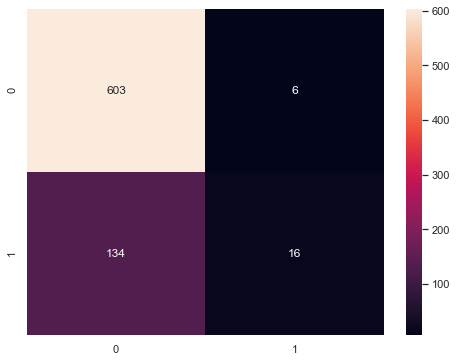

```python
import seaborn as sns
from sklearn.metrics import confusion_matrix
confusion_matrix = confusion_matrix(y_test, y_pred_dt)
plt.figure(figsize = (8,6))
sns.heatmap(confusion_matrix, annot=True, fmt="d")
```

**Table 4.** Confusion matrix after Decision Tree, cuttoff=0.5

Based on the confusion matrix, we obtained better results for TP statistics than in logistic regression and CatBoost if we use cutoff equal 0.5.

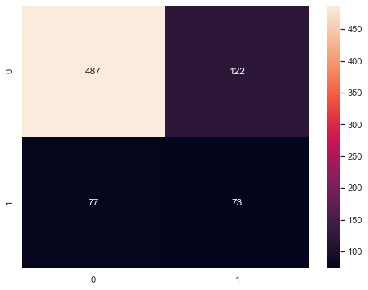

```python
import seaborn as sns
from sklearn.metrics import confusion_matrix
confusion_matrix1 = confusion_matrix(y_test, target_predict20_dt)
plt.figure(figsize = (8,6))
sns.heatmap(confusion_matrix1, annot=True, fmt="d")
```

**Table 5.** Confusion matrix after Decision Tree, cuttoff=0.2

If we use conservative approach then our cutoff = 0.2. In this case we forecast FN (False Negative) better than for cutoff = 0.5.

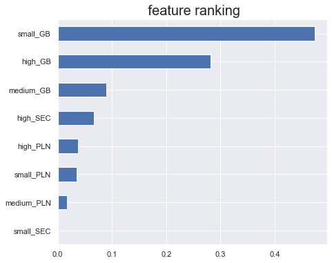

```python
sns.set()
feature_importances = pd.Series(DT.feature_importances_, index = X_train.columns).sort_values()
#Feature_importances.sort()
feature_importances.plot(kind = "barh", figsize = (7,6));
plt.title(" feature ranking", fontsize = 20)
plt.show()
```

**Graph 26.** Feature Importance statistics after Decision Tree

**4.3. Implementability of Decision Tree for sample out-of-time**

Prepare the dataset in out-of-time sample.

```python
df_OOT = pd.read_csv('/Users/nehrebeckiwp.pl/Desktop/understanding business/test_set_no_target_column.csv')
df_OOT.head(10)
```

|  | index | seconds_processing | MB_data_processed | dollars_run_cost |
| --- | --- | --- | --- | --- |
| 0 | 1 | 378.543687 | 146175.55910 | 82.554757 |
| 1 | 2 | 492.420484 | 349168.22410 | 99.734469 |
| 2 | 3 | 295.950803 | 37005.45586 | 83.442441 |
| 3 | 4 | 320.408862 | 124220.82490 | 79.157206 |
| 4 | 5 | 385.528780 | 291319.58330 | 93.179223 |
| 5 | 6 | 455.779544 | 129647.40870 | 96.033734 |
| 6 | 7 | 351.490465 | 146784.46410 | 81.985632 |
| 7 | 8 | 309.864686 | 71013.52517 | 85.324574 |
| 8 | 9 | 291.808122 | 124671.01370 | 74.220074 |
| 9 | 10 | 453.874493 | 327048.86360 | 103.557190 |

```python
#Create a new column for the amount of GB processed
df_OOT['GB_data_processed'] = df_OOT['MB_data_processed']/1000
#Create a new column for the PLN value
df_OOT['pln_run_cost'] = df_OOT['dollars_run_cost']*4.30 #average ex rate in april 22 acc to NBP mid-day rates
```

```python
#Delete unnecessary variables
del df_OOT['dollars_run_cost']
del df_OOT['MB_data_processed']
```

```python
df_OOT['GB_cat'] = pd.cut(df_OOT['GB_data_processed'],bins=[0,250,400,600], labels=['small_GB','medium_GB','high_GB'])
df_OOT['PLN_cat'] = pd.cut(df_OOT['pln_run_cost'],bins=[200,400,450,500], labels=['small_PLN','medium_PLN','high_PLN'])
df_OOT['SEC_cat'] = pd.cut(df_OOT['seconds_processing'],bins=[0,350,450,600], labels=['small_SEC','medium_SEC','high_SEC'])
```

```python
#Create dummies variables
df_OOT_dumm = df_OOT['index']
to_dummies = ['GB_cat','PLN_cat', 'SEC_cat']
for item in to_dummies:
    df_OOT_dumm = pd.concat([df_OOT_dumm, pd.get_dummies(df_OOT[item])], axis=1)
```

```python
df_OOT_dumm
```

|  | index | small_GB | medium_GB | high_GB | small_PLN | medium_PLN | high_PLN | small_SEC | medium_SEC | high_SEC |
| --- | --- | --- | --- | --- | --- | --- | --- | --- | --- | --- |
| 0 | 1 | 1 | 0 | 0 | 1 | 0 | 0 | 0 | 1 | 0 |
| 1 | 2 | 0 | 1 | 0 | 0 | 1 | 0 | 0 | 0 | 1 |
| 2 | 3 | 1 | 0 | 0 | 1 | 0 | 0 | 1 | 0 | 0 |
| 3 | 4 | 1 | 0 | 0 | 1 | 0 | 0 | 1 | 0 | 0 |
| 4 | 5 | 0 | 1 | 0 | 0 | 1 | 0 | 0 | 1 | 0 |
| ... | ... | ... | ... | ... | ... | ... | ... | ... | ... | ... |
| 995 | 996 | 1 | 0 | 0 | 1 | 0 | 0 | 1 | 0 | 0 |
| 996 | 997 | 1 | 0 | 0 | 1 | 0 | 0 | 0 | 1 | 0 |
| 997 | 998 | 0 | 0 | 1 | 0 | 0 | 0 | 0 | 0 | 0 |
| 998 | 999 | 1 | 0 | 0 | 1 | 0 | 0 | 1 | 0 | 0 |
| 999 | 1000 | 1 | 0 | 0 | 1 | 0 | 0 | 0 | 1 | 0 |

1000 rows × 10 columns

```python
df_OOT_dumm.info()
```

[output not shown]

We remain our features.

```python
df_OOT_dumm.columns = df_OOT_dumm.columns.str.lower()
print(df_OOT_dumm.columns.values)
```

```
['index' 'small_gb' 'medium_gb' 'high_gb' 'small_pln' 'medium_pln'
 'high_pln' 'small_sec' 'medium_sec' 'high_sec']
```

```python
X_OOT = df_OOT_dumm.drop(columns=['index', 'medium_sec'])
```

```python
X_OOT
```

|  | small_gb | medium_gb | high_gb | small_pln | medium_pln | high_pln | small_sec | high_sec |
| --- | --- | --- | --- | --- | --- | --- | --- | --- |
| 0 | 1 | 0 | 0 | 1 | 0 | 0 | 0 | 0 |
| 1 | 0 | 1 | 0 | 0 | 1 | 0 | 0 | 1 |
| 2 | 1 | 0 | 0 | 1 | 0 | 0 | 1 | 0 |
| 3 | 1 | 0 | 0 | 1 | 0 | 0 | 1 | 0 |
| 4 | 0 | 1 | 0 | 0 | 1 | 0 | 0 | 0 |
| ... | ... | ... | ... | ... | ... | ... | ... | ... |
| 995 | 1 | 0 | 0 | 1 | 0 | 0 | 1 | 0 |
| 996 | 1 | 0 | 0 | 1 | 0 | 0 | 0 | 0 |
| 997 | 0 | 0 | 1 | 0 | 0 | 0 | 0 | 0 |
| 998 | 1 | 0 | 0 | 1 | 0 | 0 | 1 | 0 |
| 999 | 1 | 0 | 0 | 1 | 0 | 0 | 0 | 0 |

1000 rows × 8 columns

To predict the variable 'job_result' we use Decision Tree in out of time sample.

```python
FORECAST = DT.predict(X_OOT)

FORCAST_PROB = DT.predict_proba(X_OOT)[:,1]

#If we use 0.20 as the cutoff value
FORCAST_20=[1 if i > 0.20 else 0 for i in FORCAST_PROB]
```

We will get a complete set of data by combining with the target variable.

```python
df_OOT_dumm['job_result_f']=FORECAST
```

```python
df_OOT_dumm['job_result_f_20']=FORCAST_20
```

```python
df_OOT_dumm
```

|  | index | small_gb | medium_gb | high_gb | small_pln | medium_pln | high_pln | small_sec | medium_sec | high_sec | job_result_f | job_result_f_20 |
| --- | --- | --- | --- | --- | --- | --- | --- | --- | --- | --- | --- | --- |
| 0 | 1 | 1 | 0 | 0 | 1 | 0 | 0 | 0 | 1 | 0 | 0 | 0 |
| 1 | 2 | 0 | 1 | 0 | 0 | 1 | 0 | 0 | 0 | 1 | 0 | 1 |
| 2 | 3 | 1 | 0 | 0 | 1 | 0 | 0 | 1 | 0 | 0 | 0 | 0 |
| 3 | 4 | 1 | 0 | 0 | 1 | 0 | 0 | 1 | 0 | 0 | 0 | 0 |
| 4 | 5 | 0 | 1 | 0 | 0 | 1 | 0 | 0 | 1 | 0 | 0 | 1 |
| ... | ... | ... | ... | ... | ... | ... | ... | ... | ... | ... | ... | ... |
| 995 | 996 | 1 | 0 | 0 | 1 | 0 | 0 | 1 | 0 | 0 | 0 | 0 |
| 996 | 997 | 1 | 0 | 0 | 1 | 0 | 0 | 0 | 1 | 0 | 0 | 0 |
| 997 | 998 | 0 | 0 | 1 | 0 | 0 | 0 | 0 | 0 | 0 | 0 | 1 |
| 998 | 999 | 1 | 0 | 0 | 1 | 0 | 0 | 1 | 0 | 0 | 0 | 0 |
| 999 | 1000 | 1 | 0 | 0 | 1 | 0 | 0 | 0 | 1 | 0 | 0 | 0 |

1000 rows × 12 columns

```
0    972
1     28
Name: job_result_f, dtype: int64
```

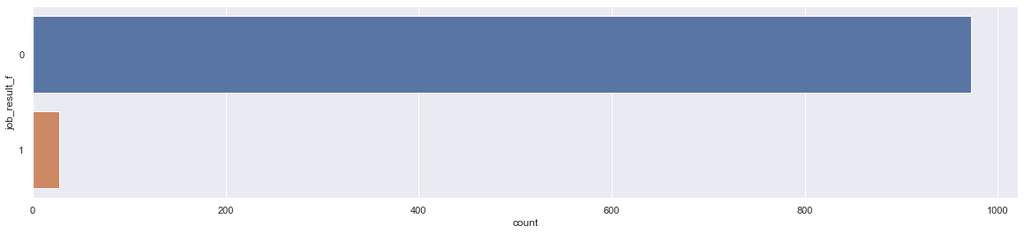

```python
fig = plt.figure(figsize=(20,4))
sns.countplot(y='job_result_f', data=df_OOT_dumm);
print(df_OOT_dumm.job_result_f.value_counts())
```

**Graph 27.** Forecast "job_result" after Deacision Tree, cuttoff=0.5

For cutoff equals 0.5 we have only failure rate about 2.8%. This is approach will be risky.

```
0    720
1    280
Name: job_result_f_20, dtype: int64
```

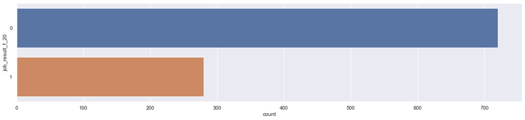

```python
fig = plt.figure(figsize=(20,4))
sns.countplot(y='job_result_f_20', data=df_OOT_dumm);
print(df_OOT_dumm.job_result_f_20.value_counts())
```

**Graph 28.** Forecast "job_result" after Deacision Tree, cuttoff=0.2

If we consider conservative approach than failure rate is equal 28%.

```python
OUTPUT = df_OOT_dumm[['index','job_result_f', 'job_result_f_20']].copy()
```

Prepeare the final dataset with consist of index and two variables:

1. job_result_f,
2. job_result_f20.

The variable 'job_result_f' presents forecasting of job_result with cutoff=0.5.  
The variable 'job_result_f20' presents forecasting of job_result with cutoff=0.2 for conservative approach.

```python
OUTPUT
```

|  | index | job_result_f | job_result_f_20 |
| --- | --- | --- | --- |
| 0 | 1 | 0 | 0 |
| 1 | 2 | 0 | 1 |
| 2 | 3 | 0 | 0 |
| 3 | 4 | 0 | 0 |
| 4 | 5 | 0 | 1 |
| ... | ... | ... | ... |
| 995 | 996 | 0 | 0 |
| 996 | 997 | 0 | 0 |
| 997 | 998 | 0 | 1 |
| 998 | 999 | 0 | 0 |
| 999 | 1000 | 0 | 0 |

1000 rows × 3 columns

```python
OUTPUT.to_csv('OUTPUT_PG.csv',index=False)
```

# 5. Conclusions

From our analysis, we know that the majority of the successful runs have lower amounts of data processed, and lower costs, however, we also noticed that for the most “heavy” 25% of data, the distinction between successes and failures is not necessarily as significant. We lack additional information on the runs of the pipelines to be able to clearly define the reason for failure. The data batches processed could differ not only in amount of data but also in structure, how complicated aggregations have to be performed, etc.

We observed that the weight has an exponential relationship with runtime and a logarithmic one with cost. This means that the heavier the batch, the runtime increases significantly with each GB. The second important conclusion is that the difference in cost is highly different for the least heavy batches, however, the more data we process, the less impact we have on cost. We lose the majority of the impact at around 80% of our successful pipelines, which is just over 230GBs.

Among the different models featured in this report (**CATBoost**, **Logistic Regression**, **Support Vector Machine**, **K-nearest neigbors**, **Naive Bayes Classifier**, **Decision Tree**, **Random Forest**, **Perceptron**, **Stochastic Gradient Descent**) the **Decision Tree** has greater accuracy.

In the forecast model of possible failed pipeline runs prior to their executions, among the evaluation components, the greatest weight was obtained for one of the basic measures - "MB_data_processed" - amount of MB that have been processed during the pipeline execution.

The statistic for the correctness of detecting failed pipeline runs (sensitivity) is the highest one for Decision Tree in comparison to others technics. From a cautious point of view, we value the low amount of false negative hits over the false positive hits, as the failed pipelines are more costly. We propose to use the conservative approach with cutoff = 0.2.

In order to improve the quality of the model in the future, it is worth considering increasing the number of observations in the data - currently the dataset under consideration covers a relatively small number of observations. Especially when using Machine Learning techniques, more observations are needed.

Additionally, it is worth collecting more information describing the behavior of data transfers between various parts of the company’s data storage architecture. It is necessary to identify the so-called strong drivers, which definitely distinguish the result of the ETL process, i.e. 'successful' or 'failed'.

At this stage, we can extract the information that we probably should decrease the amount of data processed per pipeline, by either setting a limit for the batches, or chaning their sizes in the first place. Decreasing the complexity of aggregation and batches could also have positive impact on the amount of data processed in a singular run. We know that we have “heavier” successful runs, and that’s why we can conclude that limiting the amount of data processed is not the only solution and problem to take on.

Appropriate further steps, based on the performed analysis, would be to work with data engineers on extracting additional data and information on the pipeline runs, such that would help us prepare a model with higher predicitive power, and most importantly avoid false negative predictions, as they are the most costly ones. We should also try to work with the data engineers on redesigning the batches (data bricks) to optimise the process. From a wider scope of new information, we could extract additional insights that we are missing at this stage, and understand the process and its outcomes more accurately, which in turn would lead to building a better model in order to optimise the process.

A successful project, that would help us detect possible failed pipeline runs prior to their executions would in turn help to decrease costs, which is the main goal and concern. A possible side effect could be a decrease in runtime of the entire process and decreasing the number of resources required to maintain it.